# Formulas and Model Families: Diamonds

Ray Nelson

29 March 2019

### These four functions will help us focus on linear models rather than the R code which might distract us from learning about:

- Analysis of Variance (ANOVA)
- Analysis of Covariance

```r
## Violin plot
violin_plot <- function(data_set, x, y) {
  x <- data_set[[x]]
  y <- data_set[[y]]
  tibble(x = x, y = y) %>%
    ggplot(aes(reorder(x, y, FUN = median), y)) +
    geom_violin(fill = "lightgreen") +
    geom_boxplot(width = 0.10, fill = "lightblue") +
    labs(title = "Violin Plot",
         x = "Categorical Explanatory Variable",
         y = "Response Variable")
}

## Relationship between response and explanatory
relationship <- function(data_set, x, y) {
  data_set %>%
    ggplot(aes_string(x, y)) +
    geom_point() +
    geom_smooth(method = "lm") +
    geom_smooth(colour = "red") +
    labs(title = "Relationship between response and explanatory variables",
         x = "Explanatory Variable",
         y = "Response Variable")
}

## main effects
graph_main_effects <- function(data_set, model, x, y) {
  data_set %>%
    add_predictions(model = model, var = "pred") %>%
    ggplot(aes_string(x = x, y = y, color = x)) +
    geom_point(show.legend = FALSE, position = "jitter") +
    geom_point(aes(y = pred), show.legend = FALSE, size = 5,
               color = "black", shape = 3,) +
    labs(
      title = "Visualization of different models.",
      x = "Explanatory Variable",
      y = "Response Variable"
    )
}

## Analysis of covariance
graph_predictions <- function(data_set, model, x, y, category) {
  data_set %>%
    add_predictions(model = model, var = "pred") %>%
    ggplot(aes_string(x = x, y = y, color = category)) +
    geom_point() +
    geom_line(aes(y = pred)) +
    labs(
      title = "Visualization of different models.",
      x = "Explanatory Variable",
      y = "Response Variable"
    )
}
```

### Select a subset of observations from the diamonds data frame.

```r
## Select a subset of the diamonds by taking a random sample of 1000
data(diamonds)
diamonds_subset <- diamonds %>% sample_n(1000)
diamonds_subset %>% glimpse()
```

```
## Observations: 1,000
## Variables: 10
## $ carat   <dbl> 0.61, 0.73, 0.50, 1.08, 1.01, 0.50, 0.54, 0.50, 1.08, ...
## $ cut     <ord> Good, Premium, Very Good, Ideal, Premium, Ideal, Ideal...
## $ color   <ord> E, F, D, G, E, D, D, D, E, J, J, E, F, G, I, E, G, F, ...
## $ clarity <ord> SI2, VS1, SI2, SI1, VS2, VS1, VVS1, VS2, VVS2, SI1, VS...
## $ depth   <dbl> 63.1, 61.9, 58.9, 61.7, 62.9, 62.3, 61.3, 63.4, 61.8, ...
## $ table   <dbl> 56.0, 56.0, 60.0, 56.0, 59.0, 54.3, 56.0, 56.0, 56.0, ...
## $ price   <int> 1408, 2961, 1123, 5439, 6606, 2033, 4042, 1758, 10313,...
## $ x       <dbl> 5.40, 5.81, 5.20, 6.60, 6.36, 5.05, 5.24, 5.10, 6.55, ...
## $ y       <dbl> 5.44, 5.76, 5.23, 6.63, 6.30, 5.12, 5.26, 5.05, 6.59, ...
## $ z       <dbl> 3.42, 3.58, 3.07, 4.08, 3.98, 3.17, 3.22, 3.22, 4.06, ...
```

### As considered previously, we want to consider the relationship between the price of diamonds and their cut. We can begin this exploration by using a violin plot.

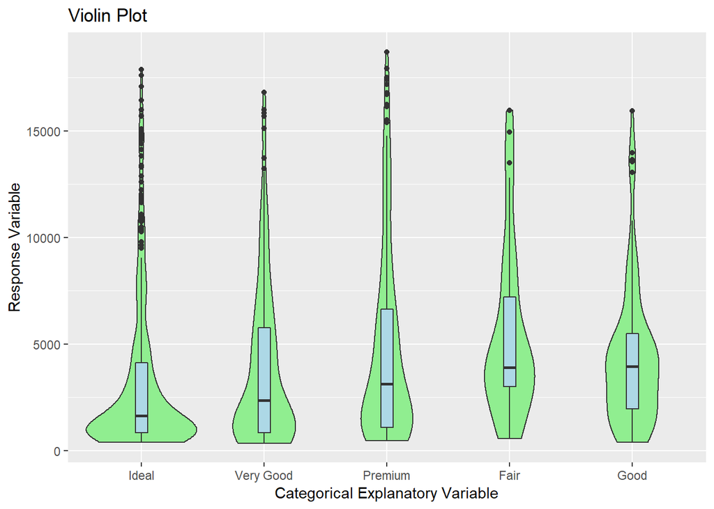

```r
violin_plot(diamonds_subset, "cut", "price")
```

### Once again, an analysis of variance model lets us predict the price of a diamond given the category of its cut. This gives us a difference in means (intercepts). Since we don’t have a numerical variable in the model, we have no slope terms in the model.

```r
zero_slope <- lm(price ~ cut, data = diamonds_subset)
zero_slope %>%  summary()
```

```
##
## Call:
## lm(formula = price ~ cut, data = diamonds_subset)
##
## Residuals:
##    Min     1Q Median     3Q    Max
##  -4849  -2591  -1582   1346  14569
##
## Coefficients:
##             Estimate Std. Error t value Pr(>|t|)
## (Intercept)   4347.6      176.8  24.595  < 2e-16 ***
## cut.L        -1175.6      460.8  -2.551  0.01088 *
## cut.Q          147.8      416.9   0.355  0.72303
## cut.C         -984.2      373.4  -2.636  0.00853 **
## cut^4         -581.9      315.1  -1.847  0.06511 .
## ---
## Signif. codes:  0 '***' 0.001 '**' 0.01 '*' 0.05 '.' 0.1 ' ' 1
##
## Residual standard error: 3959 on 995 degrees of freedom
## Multiple R-squared:  0.02901,    Adjusted R-squared:  0.02511
## F-statistic: 7.432 on 4 and 995 DF,  p-value: 6.727e-06
```

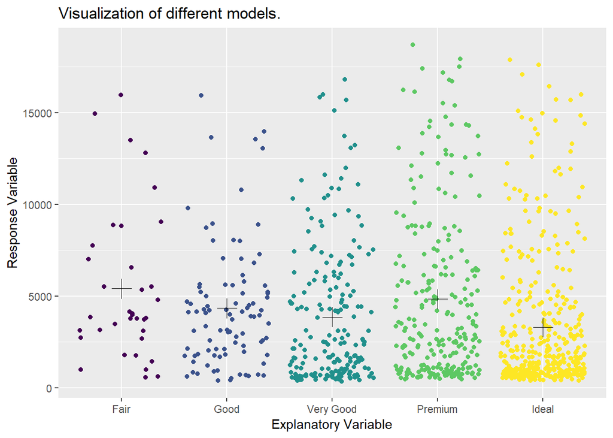

```r
graph_main_effects(diamonds_subset, zero_slope, "cut", "price")
```

### Is there a simple linear relationship between diamond price and weight measured in carats? If so, then we have a good start on creating a model that will help us predict price conditional on weight.

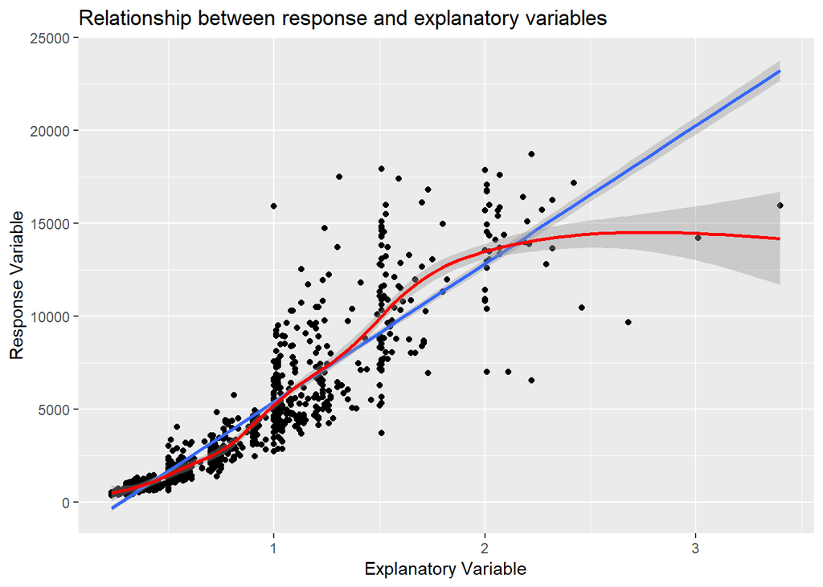

```r
relationship(diamonds_subset, "carat", "price")
```

```r
common_slope <- lm(price ~ carat + cut, data = diamonds_subset)
common_slope %>% summary()
```

```
##
## Call:
## lm(formula = price ~ carat + cut, data = diamonds_subset)
##
## Residuals:
##     Min      1Q  Median      3Q     Max
## -8598.7  -788.4   -75.2   458.7 11088.4
##
## Coefficients:
##             Estimate Std. Error t value Pr(>|t|)
## (Intercept) -2624.21     122.40 -21.439  < 2e-16 ***
## carat        7633.59     108.24  70.525  < 2e-16 ***
## cut.L        1575.15     192.16   8.197 7.53e-16 ***
## cut.Q        -722.11     170.69  -4.230 2.55e-05 ***
## cut.C         260.21     153.50   1.695   0.0904 .
## cut^4          61.19     129.00   0.474   0.6354
## ---
## Signif. codes:  0 '***' 0.001 '**' 0.01 '*' 0.05 '.' 0.1 ' ' 1
##
## Residual standard error: 1617 on 994 degrees of freedom
## Multiple R-squared:  0.8383, Adjusted R-squared:  0.8375
## F-statistic:  1030 on 5 and 994 DF,  p-value: < 2.2e-16
```

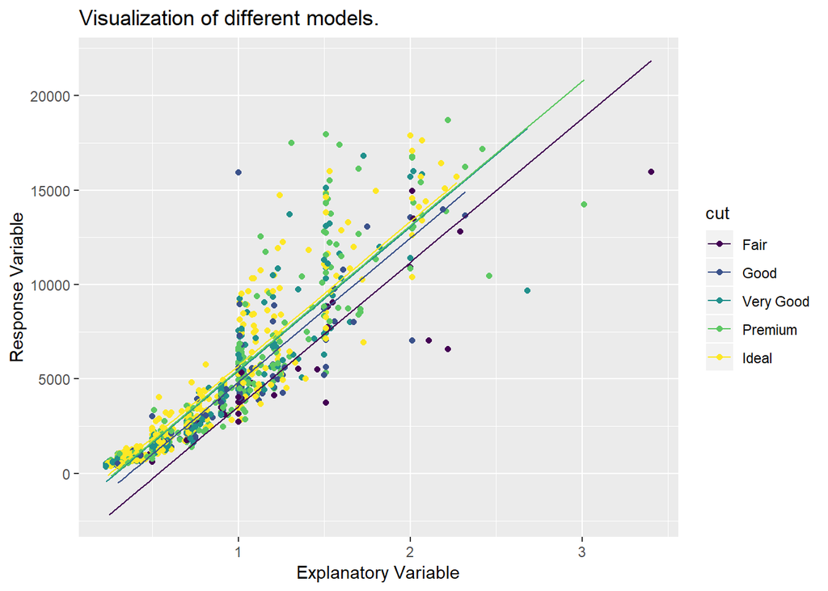

```r
graph_predictions(diamonds_subset, common_slope, "carat", "price", "cut")
```

### An analysis of covariance model also allows us to simultaneously have both categorical and numerical variables as predictors. If we include an interaction term, then each category can have a different slope and intercept.

```r
different_slopes <- lm(price ~ carat + cut + carat * cut, data = diamonds_subset)
different_slopes %>% summary()
```

```
##
## Call:
## lm(formula = price ~ carat + cut + carat * cut, data = diamonds_subset)
##
## Residuals:
##     Min      1Q  Median      3Q     Max
## -8293.7  -764.3   -86.6   492.0 11159.2
##
## Coefficients:
##             Estimate Std. Error t value Pr(>|t|)
## (Intercept) -2018.01     155.01 -13.018  < 2e-16 ***
## carat        7136.46     133.42  53.488  < 2e-16 ***
## cut.L        -568.16     402.38  -1.412   0.1583
## cut.Q         144.46     360.15   0.401   0.6884
## cut.C         163.91     337.41   0.486   0.6272
## cut^4          40.17     274.07   0.147   0.8835
## carat:cut.L  1961.81     315.52   6.218 7.42e-10 ***
## carat:cut.Q  -500.26     296.37  -1.688   0.0917 .
## carat:cut.C   -68.07     306.10  -0.222   0.8241
## carat:cut^4    95.08     273.77   0.347   0.7284
## ---
## Signif. codes:  0 '***' 0.001 '**' 0.01 '*' 0.05 '.' 0.1 ' ' 1
##
## Residual standard error: 1589 on 990 degrees of freedom
## Multiple R-squared:  0.8445, Adjusted R-squared:  0.8431
## F-statistic: 597.4 on 9 and 990 DF,  p-value: < 2.2e-16
```

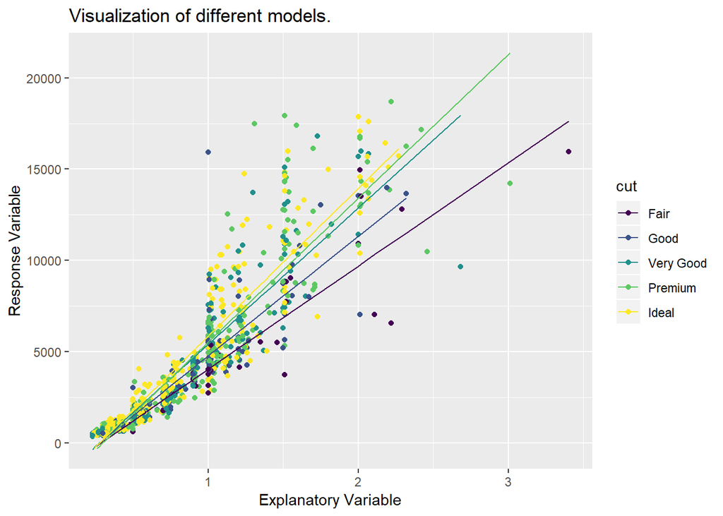

```r
graph_predictions(diamonds_subset, different_slopes, "carat", "price", "cut")
```

### We can now use the different_slopes model to predict the price of diamonds.

```r
different_slopes %>%
  predict(newdata = tibble(carat = c(0.5, 1.0), cut = c("Ideal", "Good")))
```

```
##        1        2
## 1806.324 4768.776
```